# Practical Machine Learning - Final Assignment

Chris

10 5 2018

## What you should submit?

The goal of your project is to predict the manner in which they did the exercise. This is the “classe” variable in the training set. You may use any of the other variables to predict with. You should create a report describing how you built your model, how you used cross validation, what you think the expected out of sample error is, and why you made the choices you did. You will also use your prediction model to predict 20 different test cases.

## Read and process data

First the data will be read. Then we do the partioning (70/30).

```r
train <- read.csv ("https://d396qusza40orc.cloudfront.net/predmachlearn/pml-training.csv", na.strings=c("NA","#DIV/0!", ""))
predict <- read.csv("https://d396qusza40orc.cloudfront.net/predmachlearn/pml-testing.csv", na.strings=c("NA","#DIV/0!", ""))

#select 70% as training- and 30% as testset
select <- createDataPartition(y=train$classe,p=.70,list=F)

test <- train[-select,]
train <- train[select,]
select <- NULL
```

# Datacleaning

First we remove ID-variables and timestamps (col 1:7) as they are not needed.

```r
train <- train[,-c(1:7)]
test <- test[,-c(1:7)]
```

Second we remove variables which contains NAs only.

```r
train<-train[,colSums(is.na(train)) == 0]
test <-test[,colSums(is.na(test)) == 0]
```

# Inspect target variable in training set

```r
summary(train$classe)
```

```
##    A    B    C    D    E
## 3906 2658 2396 2252 2525
```

```r
dim(train)
```

```
## [1] 13737    53
```

```r
str(train$classe)
```

```
##  Factor w/ 5 levels "A","B","C","D",..: 1 1 1 1 1 1 1 1 1 1 ...
```

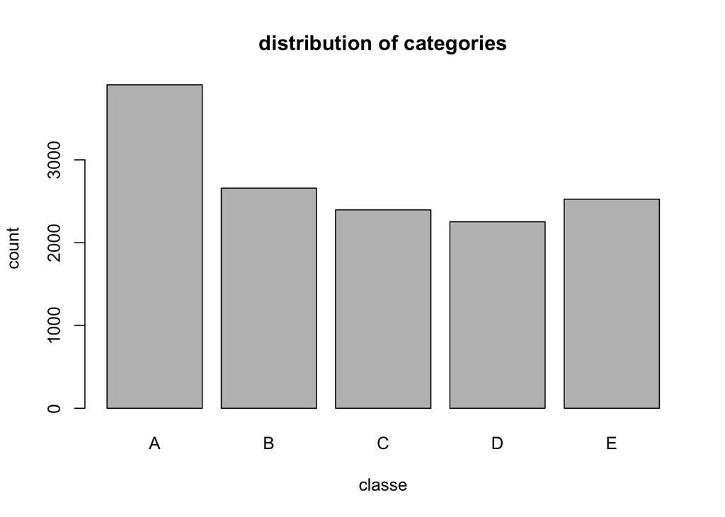

```r
plot(train$classe, ylab="count", xlab="classe", main ="distribution of categories")
```

We see, that classe is a categorial variable (factor) and that it is a little bit skewed towards class A. Therefore we need a classification algorithm, we will try two of them:

1. Random forrest
2. Simple tree

```r
#rf
model_rf <- randomForest(classe ~. , data=train, method="class")
pred_rf <- predict(model_rf, test, type = "class")
confusionMatrix(pred_rf, test$classe)[[3]][1]
```

```
##  Accuracy
## 0.9966015
```

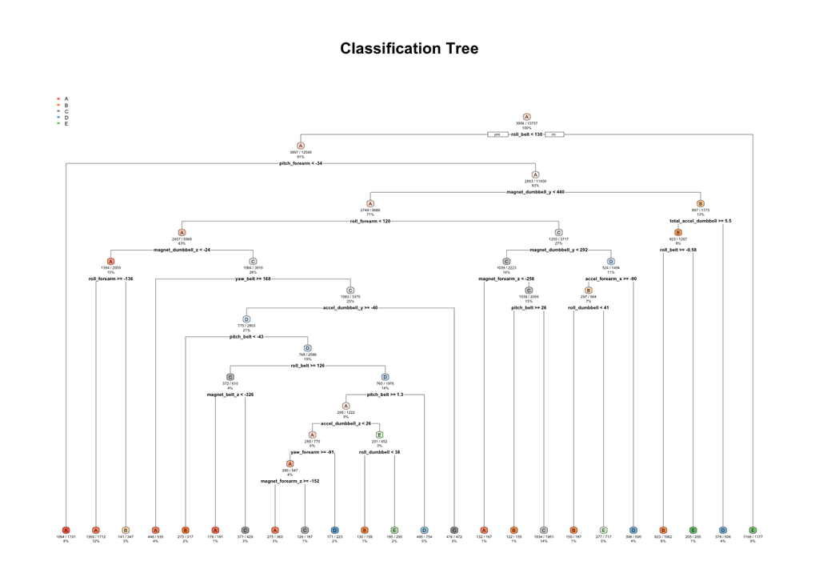

```r
#tree
model_tr <- rpart(classe ~ ., data=train, method="class")
prediction_tr <- predict(model_tr, test, type = "class")
rpart.plot(model_tr, main="Classification Tree", extra=102, under=TRUE, faclen=0)
```

```r
confusionMatrix(prediction_tr, test$classe)[[3]][1]
```

```
##  Accuracy
## 0.7442651
```